# 8 Análisis exploratorio

Autor/a

Iraitz Montalbán

Tras haber trabajado con nuestros datos originales, ya disponemos de unos datos limpios, sin datos faltantes y con cierta carga informativa.

```julia
using Parquet
using DataFrames
using CategoricalArrays

df = read_parquet(joinpath(data_path,"titanic.parquet")) |> DataFrames.DataFrame

# Primero, reemplazamos los valores numéricos por los nombres de nivel deseados
df[!, :Pclass] = replace(df[!, :Pclass], "1" => "Primera", "2" => "Segunda", "3" => "Tercera")

# Luego, convertimos la columna a categórica con los niveles y orden deseado
levels = ["Tercera", "Segunda", "Primera"]
df[!, :Pclass] = categorical(df[!, :Pclass]; levels, ordered=true)

levels = ["male", "female"]
df[!, :Sex] = categorical(df[!, :Sex]; levels, ordered=false)

describe(df)
```

7×7 DataFrame

| Row | variable Symbol | mean Union… | min Any | median Union… | max Any | nmissing Int64 | eltype Union |
| --- | --- | --- | --- | --- | --- | --- | --- |
| 1 | Survived | 0.383838 | false | 0.0 | true | 0 | Union{Missing, Bool} |
| 2 | Pclass |  | Tercera |  | Primera | 0 | Union{Missing, CategoricalValue{String, UInt32}} |
| 3 | Sex |  | male |  | female | 0 | Union{Missing, CategoricalValue{String, UInt32}} |
| 4 | Age | 29.6991 | 0.42 | 29.6991 | 80.0 | 0 | Union{Missing, Float64} |
| 5 | SibSp | 0.523008 | 0 | 0.0 | 8 | 0 | Union{Missing, Int64} |
| 6 | Parch | 0.381594 | 0 | 0.0 | 6 | 0 | Union{Missing, Int64} |
| 7 | Fare | 32.2042 | 0.0 | 14.4542 | 512.329 | 0 | Union{Missing, Float64} |

Ahora procederemos a explorar las distribuciones de datos y estadísticas de las categorías pertinentes.

## 8.1 Balance de muestras

Necesitamos evaluar si existen categoría mayoritarias en nuestro conjunto de datos. `StatsBase` nos ofrece la función `countmap` que directamente nos dará las ocurrencias de cada opción en las columnas como clave y valor de un diccionario.

```julia
Pkg.add("StatsBase")
```

```julia
using StatsBase

countmap(df[:,:Survived])
```

```
Dict{Union{Missing, Bool}, Int64} with 2 entries:
  0 => 549
  1 => 342
```

Y con `StatsPlots` podremos visualizar un gráfico de barras de cara a comparar los valores.

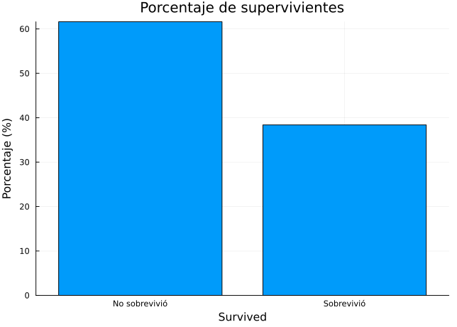

```julia
using StatsPlots

# Conteo de ocurrencias
conteo = countmap(df[:,:Survived])

# Convertir a porcentajes
total = sum(values(conteo))
porcentajes = Dict(k => v/total*100 for (k,v) in conteo)

# Etiquetas según los valores de Survived
etiquetas = ["No sobrevivió", "Sobrevivió"]
# Ordenar los porcentajes según etiquetas (asumiendo false = No sobrevivió, true = Sobrevivió)
valores = [get(porcentajes, false, 0.0), get(porcentajes, true, 0.0)]

# Graficar
bar(
    etiquetas,
    valores,
    legend=false,
    ylabel="Porcentaje (%)",
    xlabel="Survived",
    title="Porcentaje de supervivientes"
)
```

Vemos que un porcentaje superior de pasajeros (61%) no sobrevivió al Titanic.

## 8.2 Distribución de datos

Podemos querer analizar si estas dos poblaciones muestran características significativas entre sí. Algo que permita distinguir a los dos conjuntos de datos de forma significativa.

### 8.2.1 Numérica (edad)

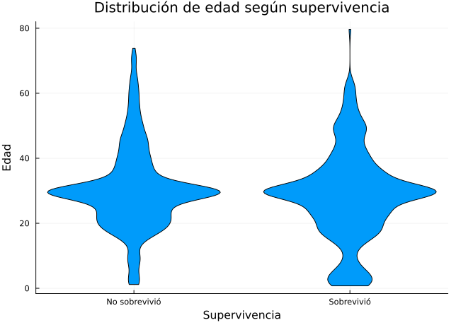

```julia
@df df violin(
    :Survived,
    :Age,
    legend=false,
    ylabel="Edad",
    xlabel="Supervivencia",
    title="Distribución de edad según supervivencia",
    xticks=([false, true], ["No sobrevivió", "Sobrevivió"])
)
```

Se observa que en el espectro más bajo de edad el conjunto de viajeros que sobrevivió es algo superior.

### 8.2.2 Categórica (sexo)

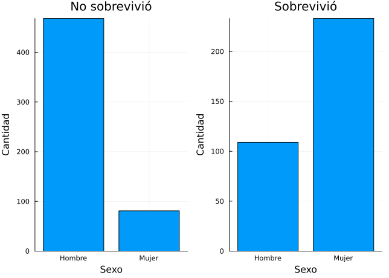

```julia
using StatsPlots

# Filtrar por supervivientes y no supervivientes
df_no = filter(:Survived => x -> x == false, df)
df_si = filter(:Survived => x -> x == true, df)

# Conteo por sexo en cada grupo
conteo_no = countmap(df_no[:, :Sex])
conteo_si = countmap(df_si[:, :Sex])

# Etiquetas y valores
etiquetas_sexo = ["Hombre", "Mujer"]
valores_no = [get(conteo_no, "male", 0), get(conteo_no, "female", 0)]
valores_si = [get(conteo_si, "male", 0), get(conteo_si, "female", 0)]

# Dibujar dos gráficas en paralelo
plot(
    bar(etiquetas_sexo, valores_no, title="No sobrevivió", legend=false, ylabel="Cantidad", xlabel="Sexo"),
    bar(etiquetas_sexo, valores_si, title="Sobrevivió", legend=false, ylabel="Cantidad", xlabel="Sexo"),
    layout=(1,2)
)
```

Vaya, aquí si que vemos dos extremos importantes. De los que sobrevivieron existe un desbalance positivo con respecto a las mujeres frente al caso de no supervivencia, donde la población de hombres fue mucho más significativa.

Posiblemente si añadieramos un eje adicional con respecto a la clase, veríamos cómo esta última característica afecta significativamente a la probabilidad de supervivencia.

### 8.2.3 De dispersión (sexo y clase)

[output not shown]

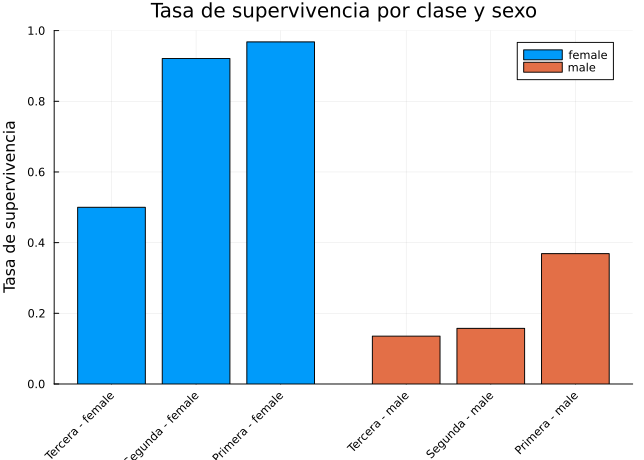

```julia
using DataFrames, StatsPlots

# Agrupar por clase y sexo, calcular tasa de supervivencia
df_group = combine(groupby(df, [:Pclass, :Sex]), :Survived => mean => :SurvivalRate)

# Convertir Sex a string para etiquetas
df_group.Sex = string.(df_group.Sex)

# Crear etiquetas combinadas para el eje x
df_group.label = string.(df_group.Pclass, " - ", df_group.Sex)

# Graficar barras agrupadas
@df df_group bar(
    :label,
    :SurvivalRate,
    group = :Sex,
    ylabel = "Tasa de supervivencia",
    legend = :topright,
    title = "Tasa de supervivencia por clase y sexo",
    bar_position = :dodge,
    ylim = (0,1),
    xrotation = 45
)
```

Vemos que la edad es también un factor a tener en cuenta y el precio del billete que de algún modo también indica la clase o ventajas abordo.

En este caso debemos ver si las distribuciones de ambas columnas muestra simetría o están volcadas a uno de los ejes (**skewness**).

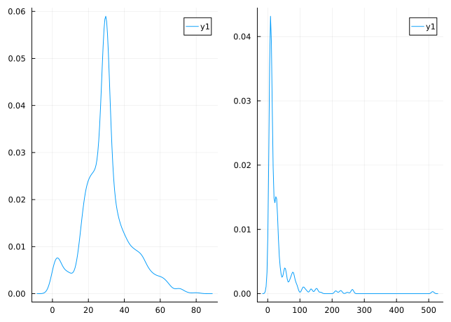

```julia
plot(
    density(df.Age),
    density(df.Fare),
    layout=(1,2)
)
```

Como podemos ver, el precio del billete muestra una asimetría significativa que dificultará un análisis visual de los datos.

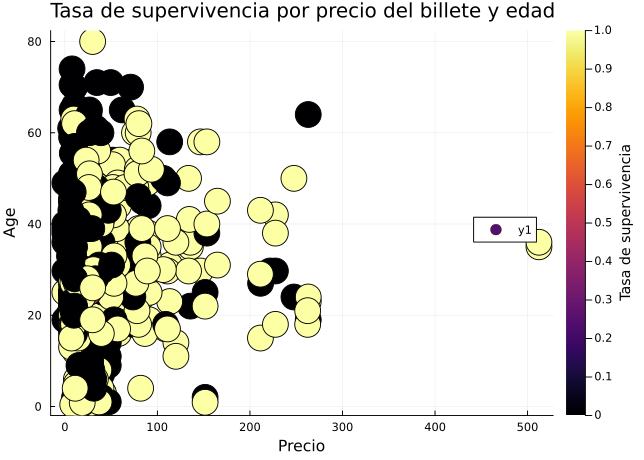

```julia
using DataFrames, StatsPlots

# Agrupamos por precio y edad, y calculamos la tasa de supervivencia
df_group = combine(groupby(df, [:Fare, :Age]), :Survived => mean => :SurvivalRate)

# Graficar: eje x = Fare, eje y = Age, color = tasa de supervivencia
@df df_group scatter(
    :Fare,
    :Age,
    markersize = 15,
    zcolor = :SurvivalRate,
    xlabel = "Precio",
    ylabel = "Age",
    title = "Tasa de supervivencia por precio del billete y edad",
    legend = :right,
    cbar_title = "Tasa de supervivencia"
)
```

Podemos compensar este hecho mediante una transformación de la distribución empleando un `logaritmo` que reduzca la distancia de los valores más anómalos contra el centro de la distribución.

**Importante**

Usaremos `log1p`, que calcula `log(1 + x)`, en lugar de `log` directamente. El motivo es que este conjunto contiene billetes con precio `0.0` (pasajeros que no pagaron) y `log(0)` devuelve `-Inf`, lo que rompería tanto el histograma como el gráfico de dispersión.

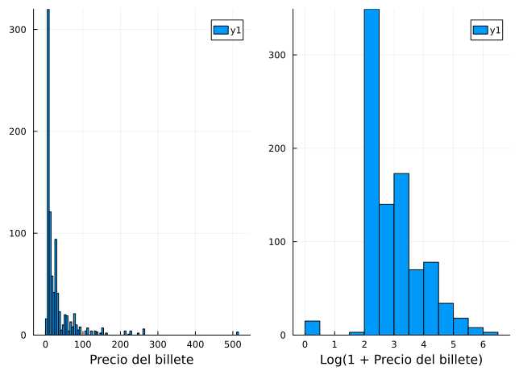

```julia
plot(
    histogram(df.Fare),
    histogram(log1p.(df.Fare)),
    layout=(1,2),
    xlabel = ["Precio del billete" "Log(1 + Precio del billete)"]
)
```

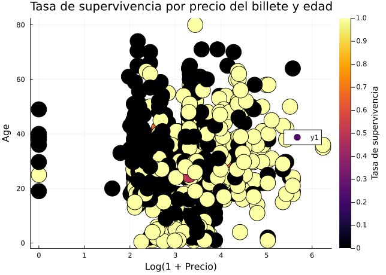

```julia
@df df_group scatter(
    log1p.(:Fare),
    :Age,
    markersize = 15,
    zcolor = :SurvivalRate,
    xlabel = "Log(1 + Precio)",
    ylabel = "Age",
    title = "Tasa de supervivencia por precio del billete y edad",
    legend = :right,
    cbar_title = "Tasa de supervivencia"
)
```

Aunque no del todo claro, ahora podemos observar mejor una mayor concentración de tasas elevadas de superviviencia para los billetes más caros.

## 8.3 Correlaciones

Aún no encontramos un ecosistema cerrado como es el caso de Scikit-learn en Python o Tidyverse en R. En este caso, para mostrar correlaciones entre pares recurriremos a la librería [PairPlots](https://sefffal.github.io/PairPlots.jl/dev/) y su dependencia actual con respecto a [Makie](https://docs.makie.org/v0.21/).

```julia
Pkg.add("PairPlots")
Pkg.add("CairoMakie")
```

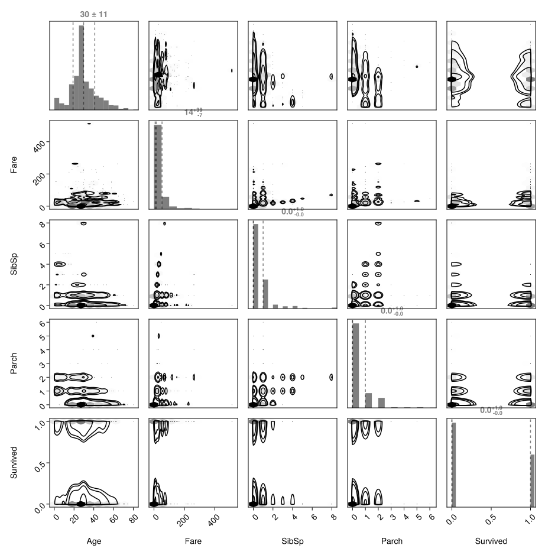

```julia
using CairoMakie
using PairPlots

# Selecciona solo columnas numéricas relevantes
cols = [:Age, :Fare, :SibSp, :Parch, :Survived]
df_num = dropmissing(df[:, cols])

pairplot(
    df_num => (
        PairPlots.HexBin(colormap=Makie.cgrad([:transparent, :black])),
        PairPlots.Scatter(filtersigma=2, color=:black),
        PairPlots.Contour(color=:black),
        PairPlots.MarginHist(),
        PairPlots.MarginQuantileText(),
        # New:
        PairPlots.MarginQuantileLines(),
    ),
    fullgrid=true
)
```

Resulta difícil ver las discrepancias así, de modo que separaremos nuestro conjunto en los dos grupos objeto de estudio.

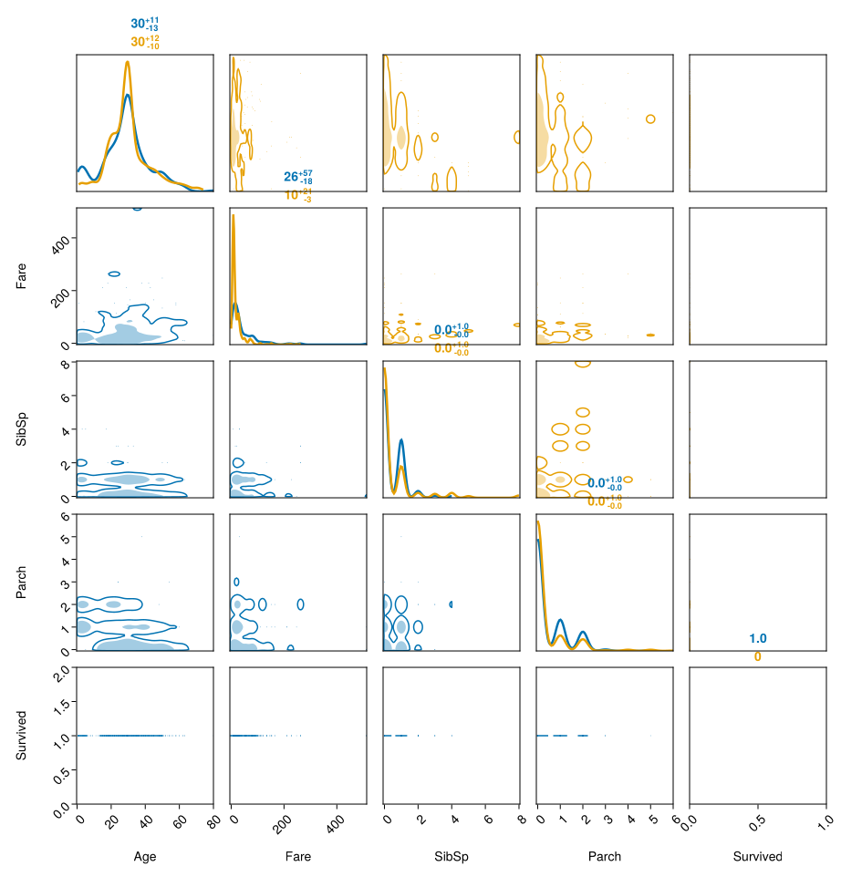

```julia
# Por categoría
df_num_survived = filter(:Survived => x -> x == true, df_num)
df_num_didntsurvive = filter(:Survived => x -> x == false, df_num)

pairplot(
    PairPlots.Series(
        df_num_survived, bottomleft=true, topright=false),
    PairPlots.Series(
        df_num_didntsurvive, bottomleft=false, topright=true)
)
```